# Random Forest Modeling

**Purpose:** We want to model the number of tumors based on the microbiome using regression via random forests

### Setup

```r
library(randomForest, quietly=TRUE)
library(knitr, quietly=TRUE)

set.seed(6201976)
source("code/rf_baseline_analysis.R")
```

```r
opts_chunk$set(dev = c("png", "cairo_pdf"))
opts_chunk$set(results = "hold")
opts_chunk$set(fig.show = "hold")
opts_chunk$set(warning = FALSE)
opts_chunk$set(fig.align = "center")
opts_chunk$set(echo = FALSE)
opts_chunk$set(cache = FALSE)
```

Let's get the relative abundance of the OTUs in our samples at baseline (Day 0). To do this, we will read in the shared file and convert the numbers to relative abundances and get the tumor count data. Using the sample names we will also extract the treatment, mouse eartag number, and the day of the experiment.

### Find the best forest

One question is how best to filter the OTU data. Let's see what happens when we alter the minimum average relative abundance across all samples:

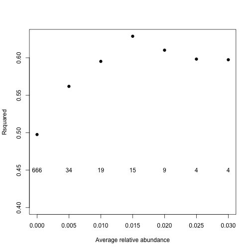

From this plot, it appears that the best threshold would be 0.015 (Rsq=0.63) and this would give us 15 OTUs. Let's press on and make sure we're using a sufficient number of trees with our threshold:

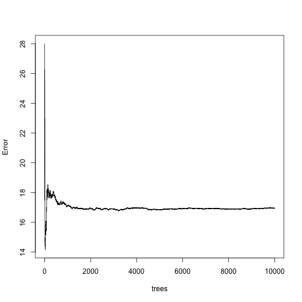

Looks like the model has stabilized at 10<sup>4</sup> trees. Let's see the importance plots:

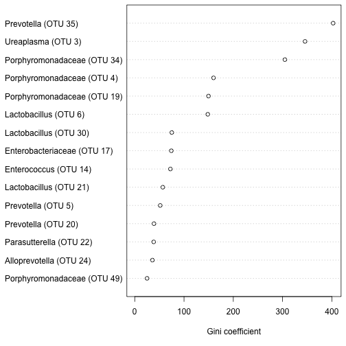

### Simplify the model

Let's sort the OTUs by their Gini coefficient and build models where we add each OTU in a stepwise manner.

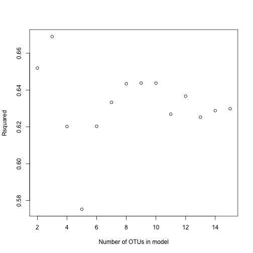

Thus, we see that the model does pretty well with just a few parameters.

### Fit data to model

Let's compare the number of predicted tumors to the number of observed tumors based on the full model.

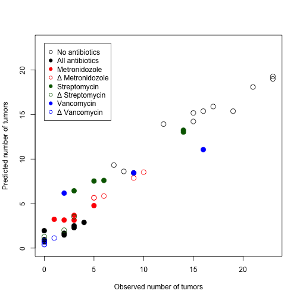

Pretty sweet!

### Plot the top six features with tumor counts

Let's generate a plot with the number of tumors on the y-axis and the OTU's relative abundance on the x-axis:

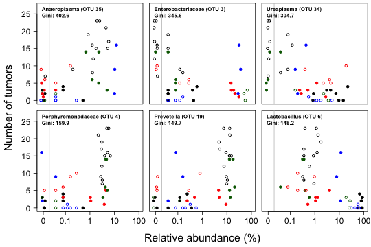

These plots highlight a few important results:

- Anaeroplasma, Porphyromonadaceae, and Prevotella increase with tumor count
- Enterobacteriaceae, Ureaplasma, and Lactobacillus decrease with tumor count